# Social Science Research Methods Analysis Script: Group 4

## Models for different dependent variables

Not all dependent variables are continuous and sometimes linear regression models can produce misleading results for these variables (but this is debated). Another common type of dependent variable is the binary variable where our outcome is the presence or absence of something. In this case we can use models that estimate the probability of an outcome occuring (typically logit or probit models). The example below is one estimate.

```r
# What if our dependent variable is a binary variable? We can run a "logit" model instead

# Let's create a binary variable for Polyarchy
modernization_data$v2x_polyarchy_binary <- ifelse(modernization_data$v2x_polyarchy > 0.5, 1, 0)

# Run a logit model of the binary Polyarchy score on GDP per capita
glm_polyarchy_gdppc <- glm(v2x_polyarchy_binary ~ e_gdppc, data = modernization_data, family = binomial)

# Print the output of the logit model
summary(glm_polyarchy_gdppc)
```

```
##
## Call:
## glm(formula = v2x_polyarchy_binary ~ e_gdppc, family = binomial,
##     data = modernization_data)
##
## Coefficients:
##              Estimate Std. Error z value Pr(>|z|)
## (Intercept) -1.940808   0.062693 -30.957   <2e-16 ***
## e_gdppc      0.078603   0.009008   8.726   <2e-16 ***
## ---
## Signif. codes:  0 '***' 0.001 '**' 0.01 '*' 0.05 '.' 0.1 ' ' 1
##
## (Dispersion parameter for binomial family taken to be 1)
##
##     Null deviance: 2653.1  on 2995  degrees of freedom
## Residual deviance: 2580.3  on 2994  degrees of freedom
##   (147 observations deleted due to missingness)
## AIC: 2584.3
##
## Number of Fisher Scoring iterations: 4
```

```r
# What is the predicted probability of a country having a Polyarchy score above 0.5 with a GDP per capita of $500?
predict(glm_polyarchy_gdppc, newdata = data.frame(e_gdppc = 0.5), type = "response")
```

```
##        1
## 0.129938
```

```r
# What is the predicted probability of a country having a Polyarchy score above 0.5 with a GDP per capita of $10,000?
predict(glm_polyarchy_gdppc, newdata = data.frame(e_gdppc = 10), type = "response")
```

```
##         1
## 0.2396173
```

```r
# What is the predicted probability of a country having a Polyarchy score above 0.5 with a GDP per capita of $20,000?
predict(glm_polyarchy_gdppc, newdata = data.frame(e_gdppc = 20), type = "response")
```

```
##         1
## 0.4088434
```

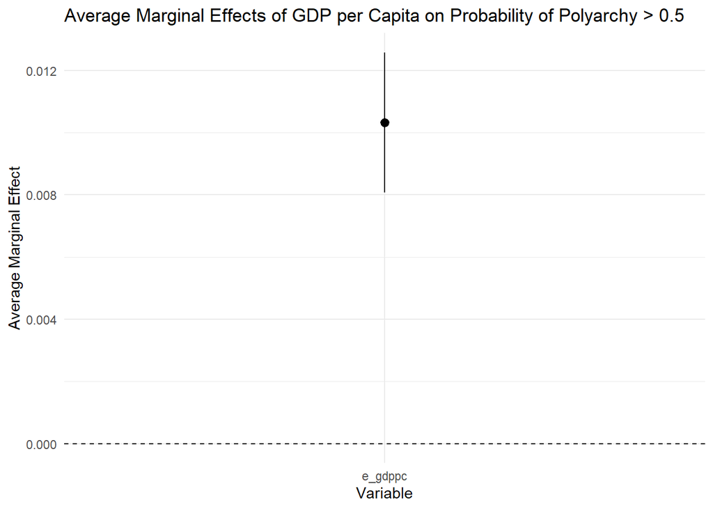

```r
# Plot the "marginal effects" of GDP per capita on the probability of having a Polyarchy score above 0.5
ggplot(summary(margins(glm_polyarchy_gdppc)),
       aes(x = factor, y = AME, ymin = lower, ymax = upper)) +
  geom_pointrange() +
  geom_hline(yintercept = 0, linetype = "dashed") +
  labs(title = "Average Marginal Effects of GDP per Capita on Probability of Polyarchy > 0.5", x = "Variable", y = "Average Marginal Effect") +
  theme_minimal()
```

## Conclusion

There are many more functions that we can use to analyse these data, and this is just a taste. We can, for example, ask if the association between two variables is dependent upon the value of another variable (an interaction effect). There are models for all types of dependent variables (binary, ordinal, categorical, continuous, count variables). We don’t need to make assumptions about the “form” of the relationship either and we can use these methods to make predictions about the future. Machine learning approaches can estimate very complicated relationships between variables and sometimes make accurate predictions if given a lot of data. There are also methods that can approximate experiments, like instrumental variable analysis.

But it’s important to remember the “hurdles” to causal inference that we discussed in class. Because there are associations does not mean that there is causality. Quantitative methods can help us to assess how closely two variables are related (Hurdle 3) and sometimes help us be more confident that alternative explanations are not accounting for our results (Hurdle 4). It can also sometimes helps lessen concerns about reverse causality (Hurdle 2). But it can’t help with whether the theory is plausible on logical grounds and there are other ways to approach the “logic” of causal inference using methods such as case studie sor QCA. Theory-building and exploratory theory work is also crucial in political science.